# Homework 4. Time series (100 points)

## Question 2

2 For this exercise use data set visitors (visitors.csv), the monthly Australian short-term overseas visitors data (thousands of people per month), May 1985–April 2005. (Total 32 points)

2.1 Make a time plot of your data and describe the main features of the series. (6 points) #Soln: We could see that there’s general upward trend over the time, which means increase of visitors overseas visitors. But I could see some decline in the visiitors near 2003 and 2004.

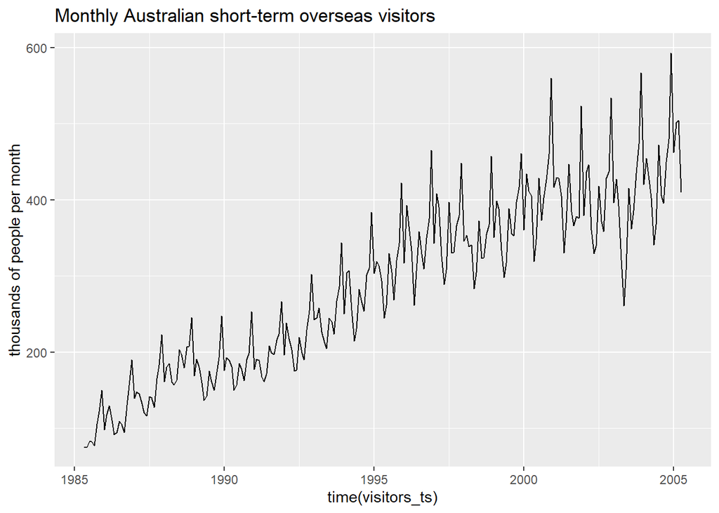

```r
visitors_df <- fread("visitors.csv") %>%
  as.data.frame()
visitors_ts <- ts(visitors_df$visitors, start = c(1985, 5),frequency = 12)
temp <- data.frame(visitors_ts)
ggplot(data = temp, aes(x = time(visitors_ts),y =visitors_ts)) +
  geom_line()+
  labs(title = "Monthly Australian short-term overseas visitors", y = "thousands of people per month")
```

2.2 Split your data into a training set and a test set comprising the last two years of available data. Forecast the test set using Holt-Winters’ multiplicative method. (6 points)

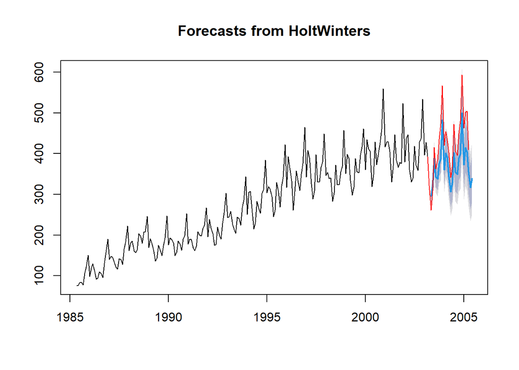

```r
train <- window(visitors_ts, end = c(2003,4))
test <- window(visitors_ts, start = c(2003,3))
visitors_Holt_Winters <- HoltWinters(train, seasonal = "multiplicative")
HoltWinters_forecast <- forecast(visitors_Holt_Winters, h = length(test))
plot(HoltWinters_forecast)
lines(test, col ="red")
```

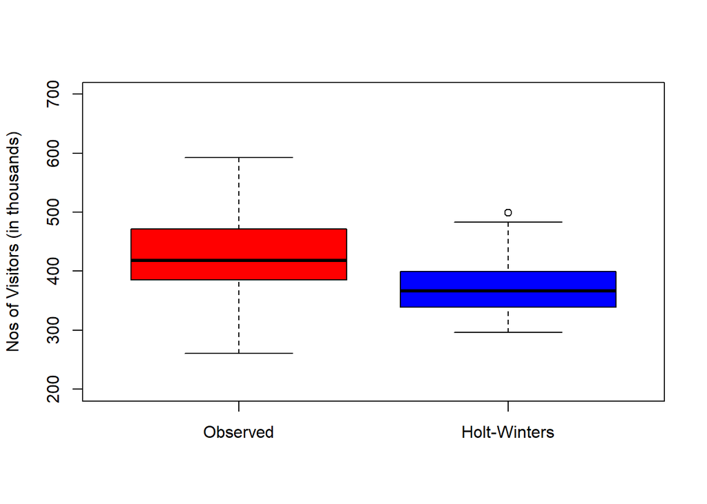

```r
ylim_range <- c(200, 700)

# Create the boxplot
boxplot(test, HoltWinters_forecast$mean,
  names = c("Observed", "Holt-Winters"),
  col = c("red", "blue"),
  ylab = "Nos of Visitors (in thousands)",
  ylim = ylim_range)
```

2.4. Forecast the two-year test set using each of the following methods: (8 points)

1. an ETS model;
2. an additive ETS model applied to a Box-Cox transformed series;
3. a seasonal naïve method;

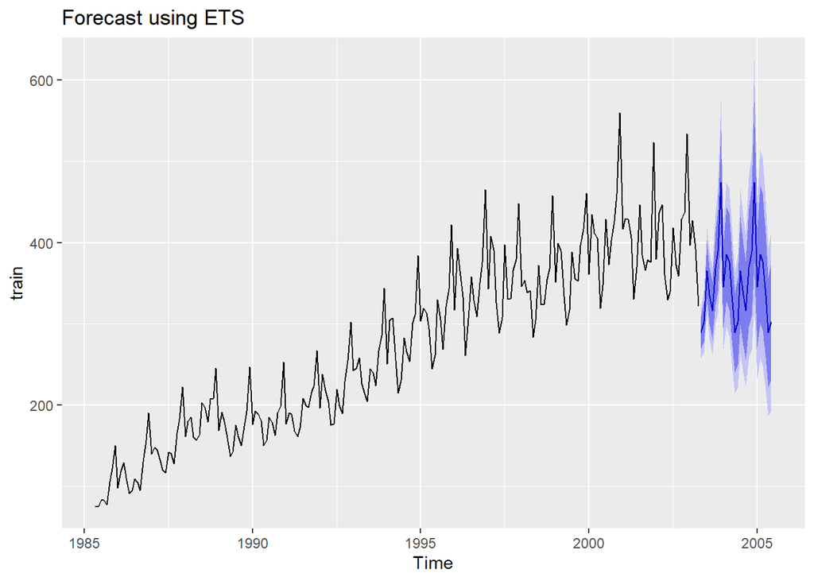

```r
#I. an ETS model;
fit_ets1 <- ets(train)
forecast_ets <- forecast(fit_ets1, h = length(test))
autoplot(forecast_ets, main = "Forecast using ETS")
```

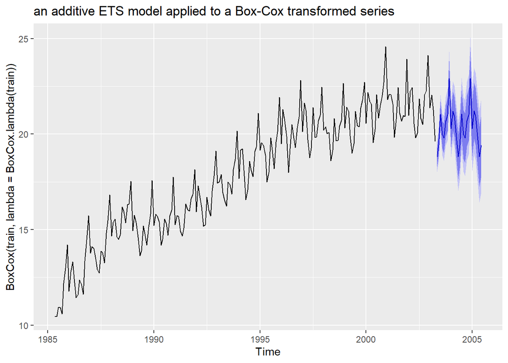

```r
#
forecast_ets_box <- forecast(ets(BoxCox(train, lambda = BoxCox.lambda(train)), model = "AAA"), h = length(test))
autoplot(forecast_ets_box, main = "an additive ETS model applied to a Box-Cox transformed series")
```

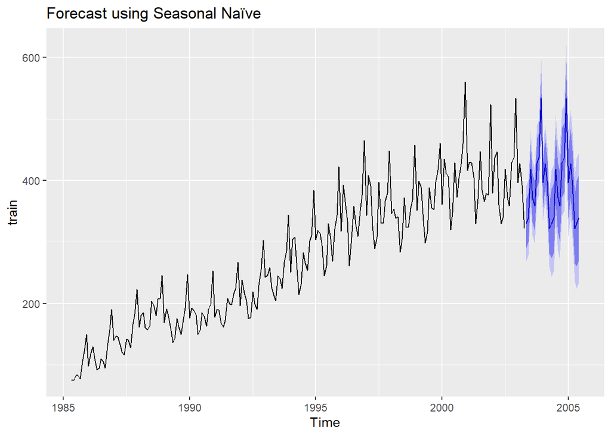

```r
#  III. a seasonal naïve method;
fit_seasonal_naive <- snaive(train,h = length(test))

autoplot(fit_seasonal_naive, main = "Forecast using Seasonal Naïve")
```

```r
rmse(HoltWinters_forecast$mean,test)
```

```
## [1] 62.67992
```

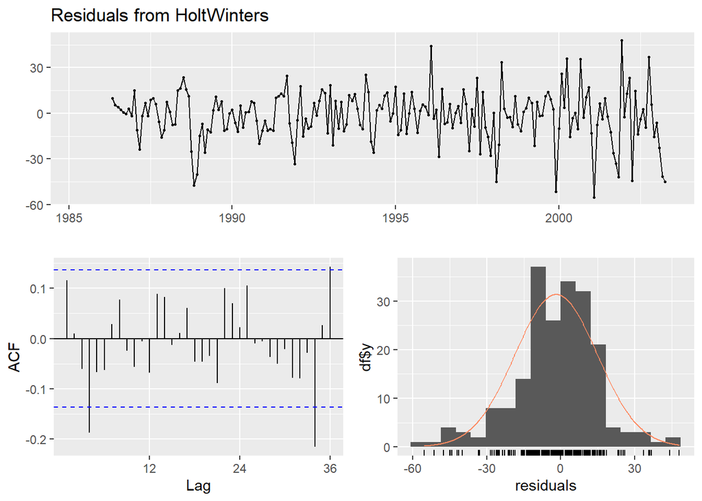

```
##
##  Ljung-Box test
##
## data:  Residuals from HoltWinters
## Q* = 26.984, df = 24, p-value = 0.3052
##
## Model df: 0.   Total lags used: 24
```

```r
checkresiduals(HoltWinters_forecast)
```

```r
rmse(forecast_ets$mean,test)
```

```
## [1] 80.23124
```

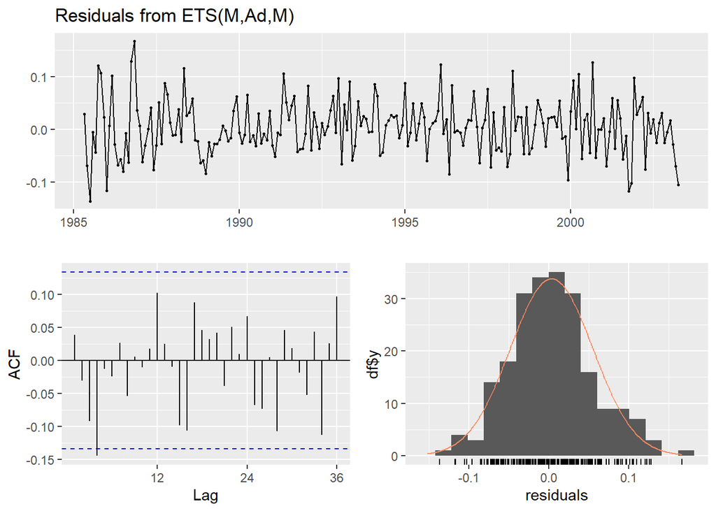

```
##
##  Ljung-Box test
##
## data:  Residuals from ETS(M,Ad,M)
## Q* = 20.677, df = 24, p-value = 0.6577
##
## Model df: 0.   Total lags used: 24
```

```r
checkresiduals(forecast_ets)
```

```r
rmse(fit_seasonal_naive$mean,test)
```

```
## [1] 50.30097
```

## Question 3

3. Consider usmelec (usmelec.csv), the total net generation of electricity (in billion kilowatt hours) by the U.S. electric industry (monthly for the period January 1973 – June 2013). In general there are two peaks per year: in mid-summer and mid-winter. (Total 36 points)

3.1 Examine the 12-month moving average of this series to see what kind of trend is involved. (4 points) #I could oberserve general upward trend with time.

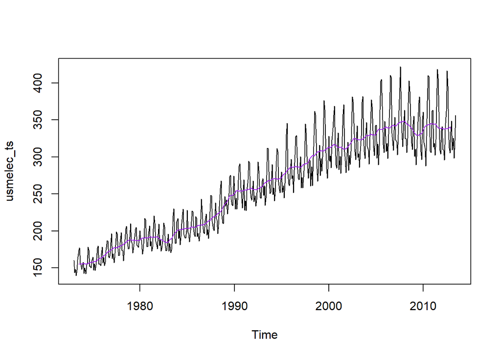

```r
usmelec_df <- fread("usmelec.csv") %>%
  as.data.frame()
usmelec_ts <- ts(usmelec_df$value, start = c(1973, 1), end = c(2013,6), frequency = 12)
plot(usmelec_ts, col="black")
lines(ma(usmelec_ts,order = 12),col="purple")
```

3.2 Do the data need transforming? If so, find a suitable transformation. (4 points) #Yes we need transformation, below is the transformed data. I did log transformation said by professor in lecture.

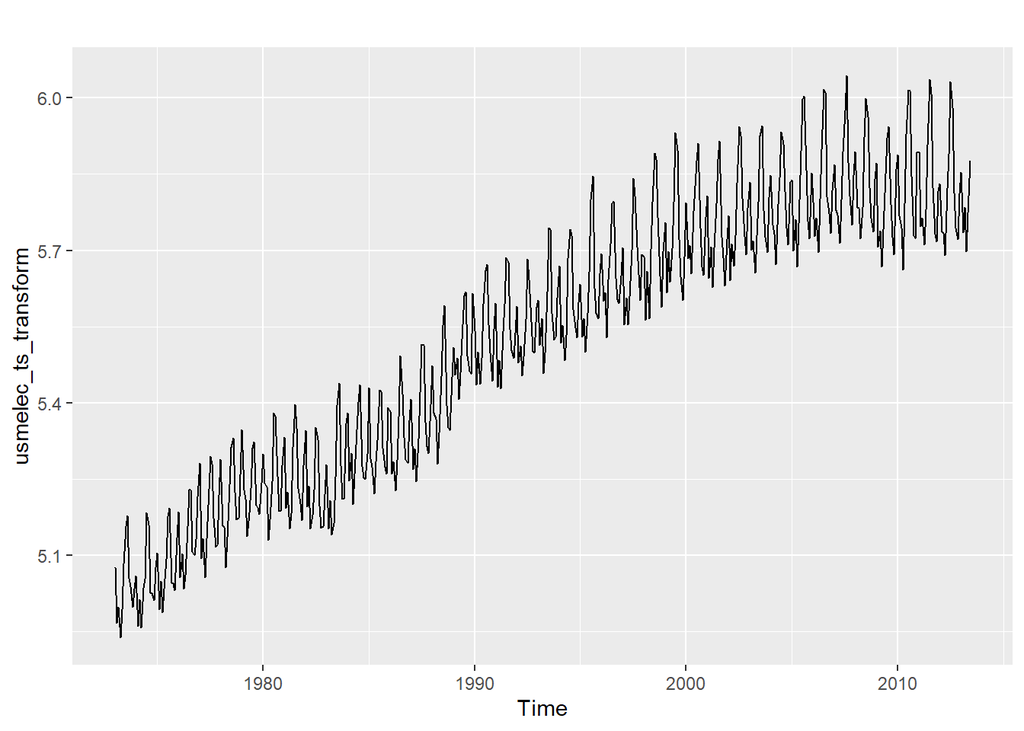

```r
usmelec_ts_transform <- log(usmelec_ts)
autoplot(usmelec_ts_transform)
```

3.3 Are the data stationary? If not, find an appropriate differencing which yields stationary data. (4 points) #The data is not stationary

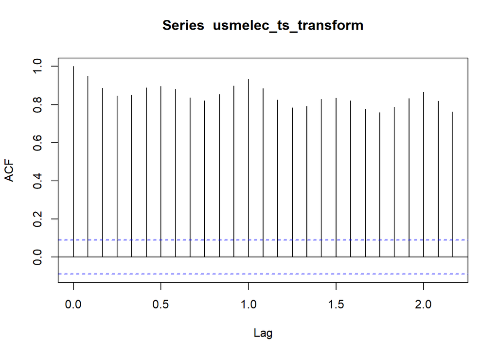

```r
acf(usmelec_ts_transform)
```

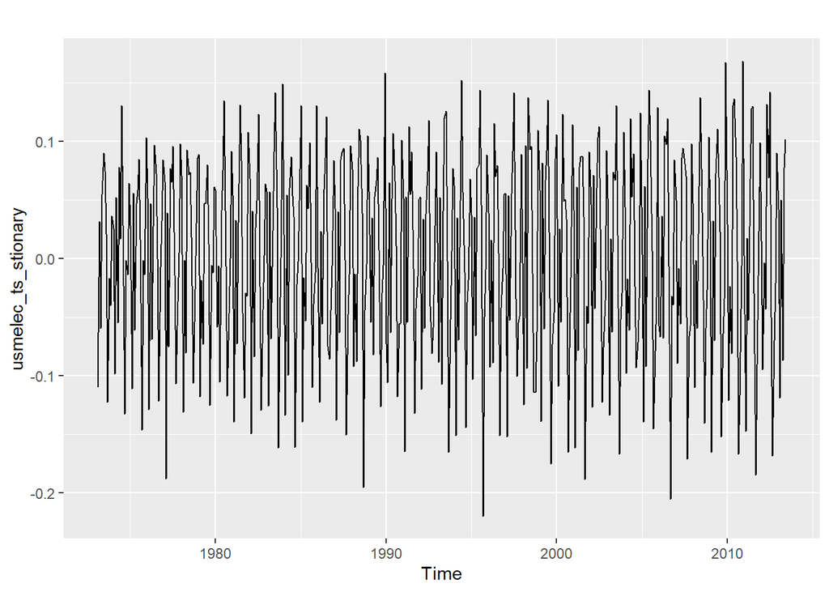

```r
usmelec_ts_stionary <- diff(usmelec_ts_transform)
autoplot(usmelec_ts_stionary)
```

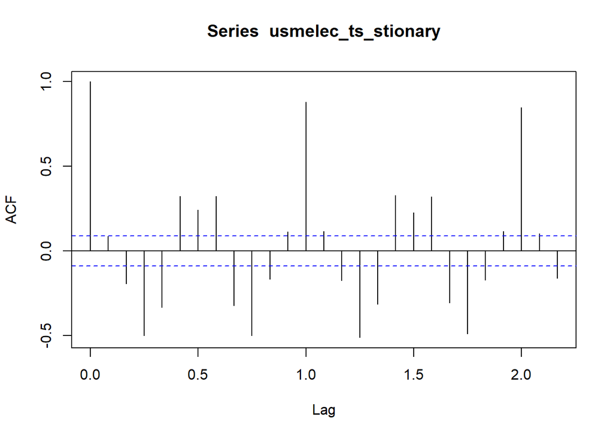

```r
acf(usmelec_ts_stionary)
```

3.4 Identify a couple of ARIMA models that might be useful in describing the time series. Which of your models is the best according to their AIC values? (6 points) #As per AIC values auto.arima (AIC=-2081.69) is best.

```r
model1 <- Arima(usmelec_ts_stionary, order=c(4, 1, 0))
summary(model1)
```

```
## Series: usmelec_ts_stionary
## ARIMA(4,1,0)
##
## Coefficients:
##           ar1      ar2      ar3      ar4
##       -0.6510  -0.4148  -0.6149  -0.6471
## s.e.   0.0347   0.0360   0.0357   0.0347
##
## sigma^2 = 0.005968:  log likelihood = 553.27
## AIC=-1096.54   AICc=-1096.42   BIC=-1075.63
##
## Training set error measures:
##                        ME       RMSE        MAE      MPE     MAPE     MASE
## Training set 0.0004875977 0.07685262 0.06077432 145.9185 283.7756 2.019398
##                    ACF1
## Training set -0.1268654
```

```r
model2 <- Arima(usmelec_ts_stionary, order = c(2, 1, 0))
summary(model2)
```

```
## Series: usmelec_ts_stionary
## ARIMA(2,1,0)
##
## Coefficients:
##           ar1      ar2
##       -0.3872  -0.1188
## s.e.   0.0452   0.0452
##
## sigma^2 = 0.01154:  log likelihood = 393.91
## AIC=-781.81   AICc=-781.76   BIC=-769.26
##
## Training set error measures:
##                        ME      RMSE        MAE      MPE     MAPE  MASE
## Training set 0.0005584085 0.1071007 0.08835969 492.3506 692.0716 2.936
##                     ACF1
## Training set -0.04008904
```

```r
model3 <- Arima(usmelec_ts_stionary, order = c(0, 1, 1))
summary(model3)
```

```
## Series: usmelec_ts_stionary
## ARIMA(0,1,1)
##
## Coefficients:
##           ma1
##       -1.0000
## s.e.   0.0052
##
## sigma^2 = 0.007281:  log likelihood = 501.88
## AIC=-999.75   AICc=-999.73   BIC=-991.39
##
## Training set error measures:
##                        ME       RMSE       MAE      MPE     MAPE     MASE
## Training set 0.0005114272 0.08515432 0.0723278 98.41782 108.6833 2.403295
##                    ACF1
## Training set 0.08804448
```

```r
auto_model <- auto.arima(usmelec_ts_stionary)
summary(auto_model)
```

```
## Series: usmelec_ts_stionary
## ARIMA(1,0,1)(2,1,1)[12] with drift
##
## Coefficients:
##          ar1      ma1    sar1     sar2     sma1  drift
##       0.4196  -0.8569  0.0119  -0.1014  -0.8257      0
## s.e.  0.0619   0.0348  0.0565   0.0531   0.0359      0
##
## sigma^2 = 0.0006822:  log likelihood = 1047.85
## AIC=-2081.69   AICc=-2081.45   BIC=-2052.58
##
## Training set error measures:
##                        ME       RMSE        MAE       MPE     MAPE      MASE
## Training set 0.0003631124 0.02563002 0.01952966 -7.924451 106.9543 0.6489281
##                     ACF1
## Training set 0.006946614
```

```r
model5 <- Arima(usmelec_ts_stionary, order = c(2, 0, 2))
summary(model5)
```

```
## Series: usmelec_ts_stionary
## ARIMA(2,0,2) with non-zero mean
##
## Coefficients:
##          ar1      ar2      ma1     ma2    mean
##       1.0436  -0.6293  -1.3345  0.3923  0.0016
## s.e.  0.0686   0.0417   0.0870  0.0826  0.0003
##
## sigma^2 = 0.004448:  log likelihood = 626.3
## AIC=-1240.6   AICc=-1240.42   BIC=-1215.49
##
## Training set error measures:
##                         ME      RMSE        MAE      MPE     MAPE     MASE
## Training set -0.0001097452 0.0663514 0.05287293 6.665012 217.8532 1.756852
##                     ACF1
## Training set -0.03883998
```

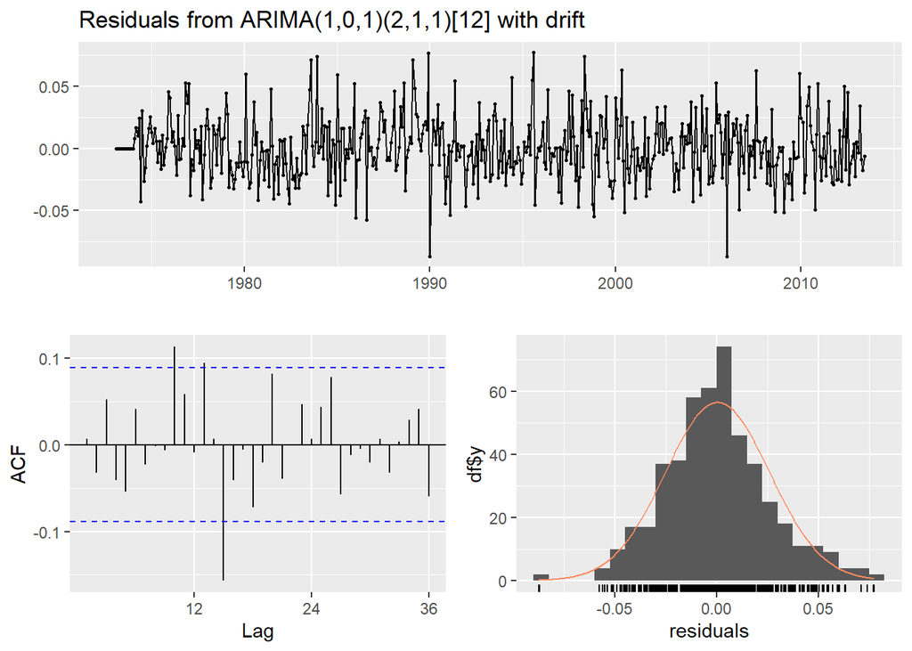

```
##
##  Ljung-Box test
##
## data:  Residuals from ARIMA(1,0,1)(2,1,1)[12] with drift
## Q* = 39.21, df = 19, p-value = 0.004149
##
## Model df: 5.   Total lags used: 24
```

```r
best_model <- auto_model
checkresiduals(best_model)
```

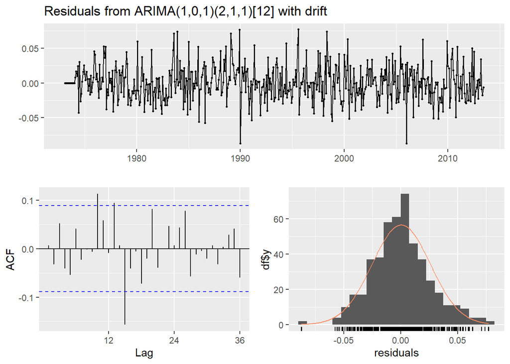

```
##
##  Ljung-Box test
##
## data:  Residuals from ARIMA(1,0,1)(2,1,1)[12] with drift
## Q* = 39.21, df = 19, p-value = 0.004149
##
## Model df: 5.   Total lags used: 24
```

```r
final_model <- Arima(usmelec_ts, order = c(1, 0, 1), seasonal = c(2, 1, 1), include.drift = TRUE)
final_model1 <- Arima(usmelec_ts_stionary, order = c(1, 0, 1), seasonal = c(2, 1, 1), include.drift = TRUE)
checkresiduals(final_model1)
```

```r
summary(final_model1)
```

```
## Series: usmelec_ts_stionary
## ARIMA(1,0,1)(2,1,1)[12] with drift
##
## Coefficients:
##          ar1      ma1    sar1     sar2     sma1  drift
##       0.4196  -0.8569  0.0119  -0.1014  -0.8257      0
## s.e.  0.0619   0.0348  0.0565   0.0531   0.0359      0
##
## sigma^2 = 0.0006822:  log likelihood = 1047.85
## AIC=-2081.69   AICc=-2081.45   BIC=-2052.58
##
## Training set error measures:
##                        ME       RMSE        MAE       MPE     MAPE      MASE
## Training set 0.0003631124 0.02563002 0.01952966 -7.924451 106.9543 0.6489281
##                     ACF1
## Training set 0.006946614
```

3.6 Forecast the next 15 years of electricity generation by the U.S. electric industry. Get the latest figures from the EIA (https://www.eia.gov/totalenergy/data/monthly/#electricity) to check the accuracy of your forecasts. (8 points)

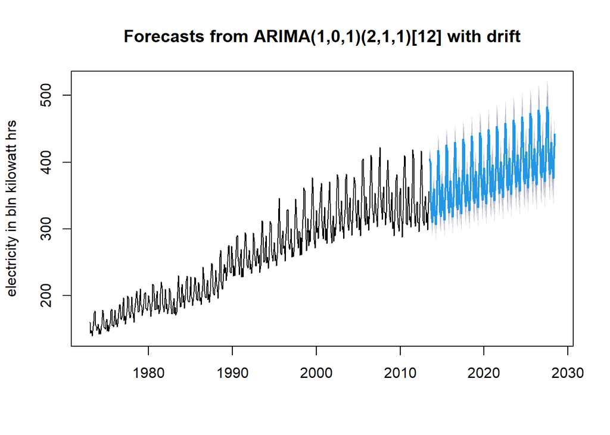

```r
plot(forecast(final_model,h =180), ylab = "electricity in bln kilowatt hrs")
lines(ma(usmelec_ts_stionary, 12), col = "red")
```

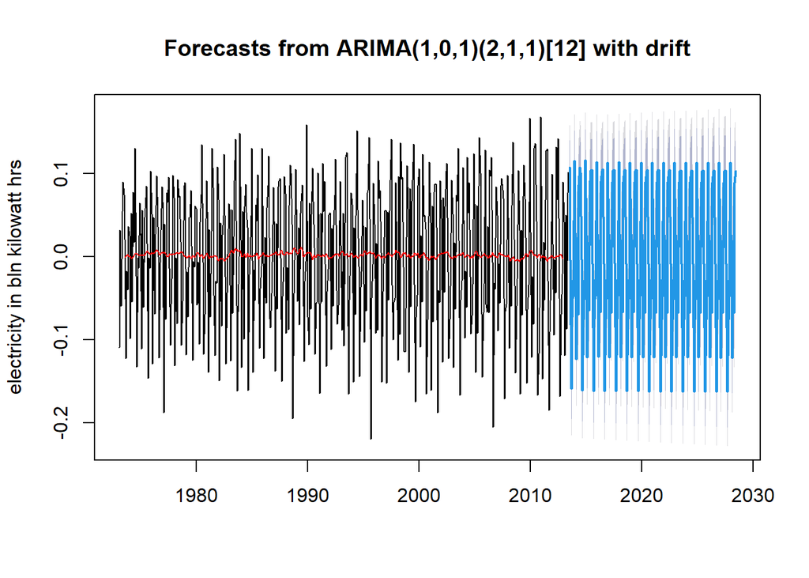

```r
plot(forecast(final_model1,h =180), ylab = "electricity in bln kilowatt hrs")
lines(ma(usmelec_ts_stionary, 12), col = "red")
```

3.7. Eventually, the prediction intervals are so wide that the forecasts are not particularly useful. How many years of forecasts do you think are sufficiently accurate to be usable? (6 points)

```r
#I feel that forecast usually lose their practicality when the range increase more than 5 years. In our case we took 15 years for predication.

#There can be several reasons for having the expansion f prediction intervals. One can be non-stationary of the data, where the moders basically fails to capture the underlying patterns, so its important to make it stationary first. 2nd I feel its important to look for outliers, this can be a very important issue as the increase the width between the prediction intervals.
#Also more the complex is the model, more is the chance of wider prediction intervals, this may happen for overfitting of the data.
# Also its important to transform the data this reduces the width.

#In our case wide prediction intervals are due to the seasonality and complexity of the data.
```